# Text as Data Homework 3

Vanessa (Ziwei) Xu and zx657

2022-04-27

```
## [[1]]
## [1] TRUE
##
## [[2]]
## [1] TRUE
##
## [[3]]
## [1] TRUE
##
## [[4]]
## [1] TRUE
```

## Q1a

Since the corpus of text is very large and my boss needs the model as soon as possible, I would choose to use variational inference method as it produces results very quickly compared to the other two LDA methods. This is because variational inference is simply simplifying the original problem and make an approximation instead.

## Q1b

By changing the values of alpha (prior), we have three approaches in selecting the number of topics, k, for the model. Setting a high alpha, alpha > 1, multiple topics will be selected. Setting a low alpha, alpha < 1, typically one topic (or only a few) is selected in each document. Setting a uniform alpha, alpha = 1, some ducoments might have one topic and other will have multiple topics.

## Q1c (i)

The hyperparameter to cause very sparse topics would be a very small alpha (prior).

## Q1c (ii)

A large prior on beta, eta, would be the cause of a flat topic-word distribution, where each topic assigns a similar probability to each word within the topic.

## Q1d

Having full uncertainty estimates around all parameters and without worrying runtime, EM would be the fitting method I would select because both Gibbs and Variational inference are approximations of EM.

## Q1e

Words in the document are not independent of each other after conditioning on the topic θi because they are from the same distribution beta.

p(w|θ,β) = ∑p(w|z,β)p(z|θ).

## Q2a

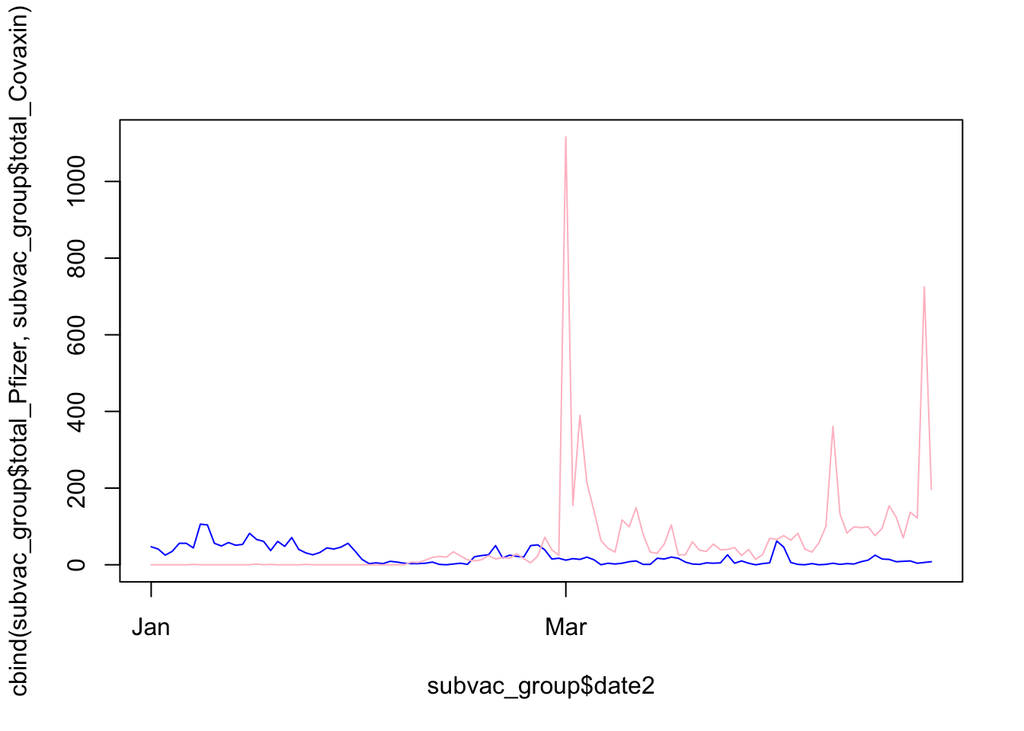

```r
# load the csv file first
path <- "/Users/vanessaxu/Desktop/school/1015/homework/vaccination_all_tweets.csv"
vac <- read.csv(path)
# subset data
vac$date2 <- as.Date(vac$date)
subvac <- vac[which(vac$date2 <= '2021-04-30' & vac$date2 >= '2021-01-01'),]
subvac <- subvac[grepl('PfizerBioNTech', subvac$hashtags) | grepl('Covaxin', subvac$hashtags),]
# plot tweets
subvac$Pfizer <- ifelse(grepl('PfizerBioNTech', subvac$hashtags),1,0)
subvac$Covaxin <- ifelse(grepl('Covaxin', subvac$hashtags),1,0)
View(subvac)
subvac_group <- subvac %>% group_by(date2) %>%
                            summarise(total_Pfizer = sum(Pfizer),
                              total_Covaxin = sum(Covaxin),
                              .groups = 'drop')
View(subvac_group)
matplot(subvac_group$date2, cbind(subvac_group$total_Pfizer, subvac_group$total_Covaxin), type="l", col=c("blue","pink"), lty=c(1,1))
```

The blue line is count of tweets mentioning PfizerBioNTech and pink line mentioning Covaxin.

## Q2c

```r
# Remove non ASCII characters
subvac$text <- stringi::stri_trans_general(subvac$text, "latin-ascii")
# Removes solitary letters
subvac$text <- gsub(" [A-z] ", " ", subvac$text)

vac_data <- textProcessor(subvac$text, metadata = subvac,
                          lowercase = TRUE, removestopwords = TRUE, removenumbers = TRUE,
                          removepunctuation = TRUE, stem = FALSE)
```

```
## Building corpus...
## Converting to Lower Case...
## Removing punctuation...
## Removing stopwords...
## Removing numbers...
## Creating Output...
```

```r
vac_data
```

```
## A text corpus with 9417 documents, and an 20280 word dictionary.
```

```r
# Create DFM to delete rare words
# vac_dfm <-dfm(subvac$text, stem = F, remove_punct = T, tolower = T, remove_numbers = TRUE, remove = c(stopwords("english")))
#vac_dfm <- dfm_trim(vac_dfm, min_docfreq = 0.00011, docfreq_type = "prop")
```

## Q2d

```r
vac_data <- prepDocuments(vac_data$documents, vac_data$vocab,
                          meta = subvac, lower.thresh = 30)
```

```
## Removing 19908 of 20280 terms (40884 of 93405 tokens) due to frequency
## Removing 2 Documents with No Words
## Your corpus now has 9415 documents, 372 terms and 52521 tokens.
```

```r
vac_data$meta$date2 <- as.numeric(vac_data$meta$date2)
#system.time(
#  vac_stm <- stm(vac_data$documents, vac_data$vocab, 10, prevalence = ~Pfizer + s(date2),
#                 data = vac_data$meta))
# saveRDS(vac_stm, "vac_stm.rds")
vac_stm <- readRDS("vac_stm.rds")
cat('Number of iteration it took to converge:',vac_stm$convergence$its)
```

```
## Number of iteration it took to converge: 33
```

## Q2e

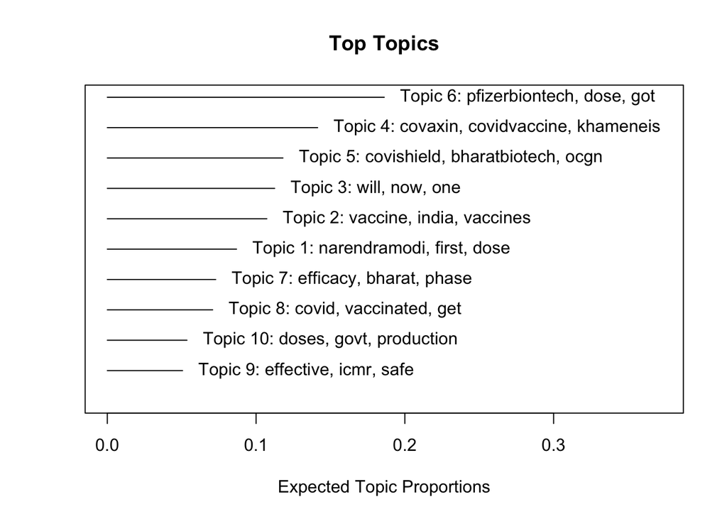

```r
# A summary plot of the topics that ranks them by their average proportion in the corpus
plot(vac_stm, type = "summary")
```

5 topics that occur in the highest proportion of documents: Top 1: pfizerbiotech, dose, got Top 2: covaxin, covidvaccine, khameneis Top 3: covishield, bharatbiotech, ocgn Top 4: will, now, one Top 5: vaccine, india, vaccines

## Q2f

```r
# system.time(
#   vac_stm2 <- stm(vac_data$documents, vac_data$vocab, 20, prevalence = ~Pfizer + s(date2),
#                  data = vac_data$meta))
# saveRDS(vac_stm2, "vac_stm2.rds")
vac_stm2 <- readRDS("vac_stm2.rds")
cat('Number of iteration it took to converge:',vac_stm2$convergence$its)
```

```
## Number of iteration it took to converge: 168
```

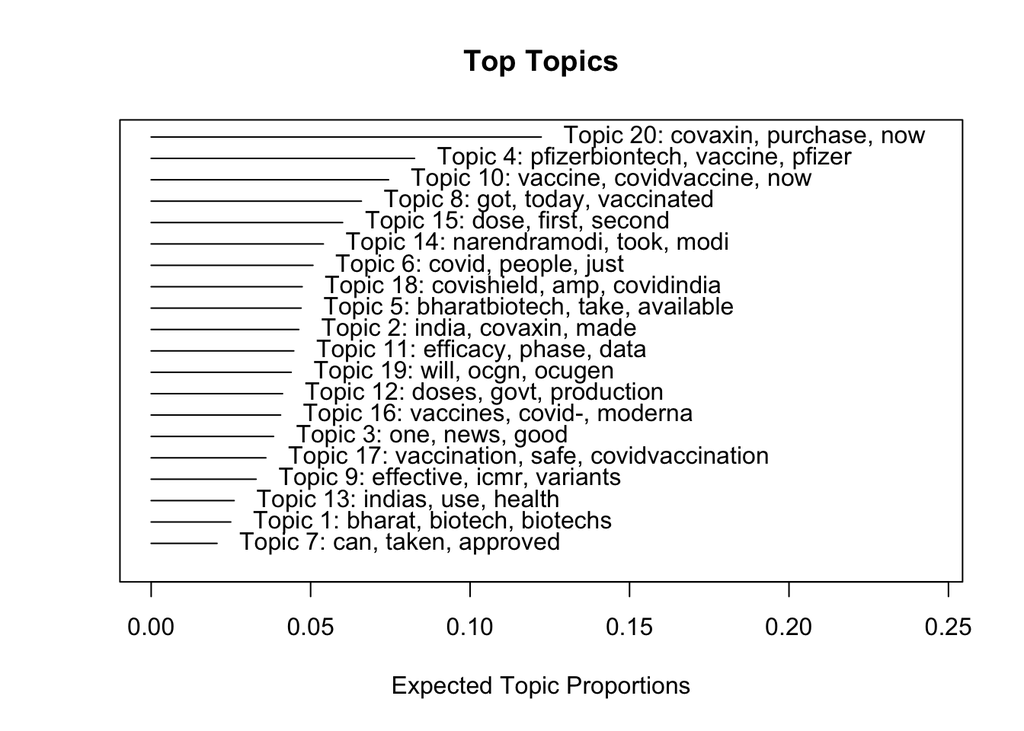

```r
# A summary plot of the topics that ranks them by their average proportion in the corpus
plot(vac_stm2, type = "summary")
```

## Q2g

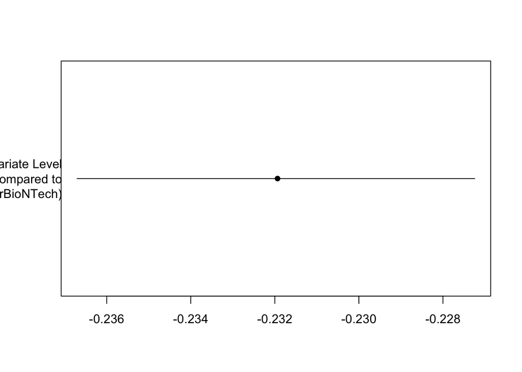

```r
prep <- estimateEffect(1:20 ~Pfizer + s(date2), vac_stm2, meta = vac_data$meta)
# content variation with vaccines
plot(prep, "Pfizer", model = vac_stm2, topics = c(4),
     method = "difference", cov.value1 = "Covaxin", cov.value2 = "PfizerBioNTech")
```

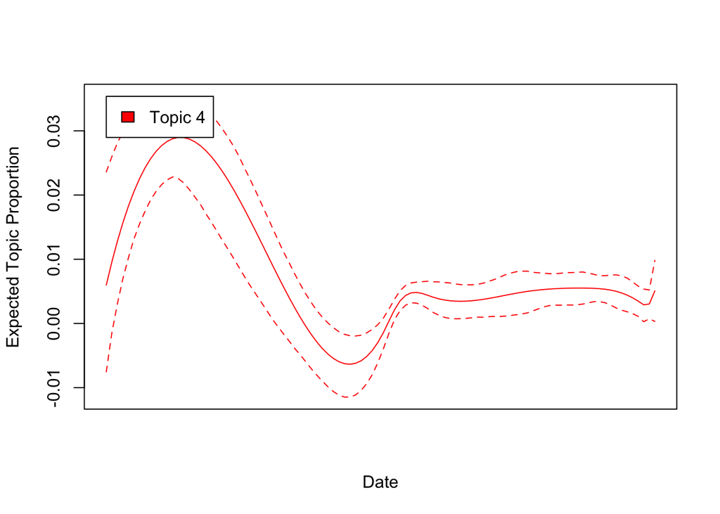

```r
# Plots the distribution of topics over time
plot(prep, "date2", vac_stm2, topics = c(4),
     method = "continuous", xaxt = "n", xlab = "Date")
```

I decided to choose topic 4, which have both pfizerbiotech and pfizer. The covariate level of covaxin compared to pfizerbiontech is about -0.231. And prevalence changed over time as more people talk about it at the beginning and drops over time. This is expected as Pfizer was rather popular when the vaccine first came out and fewer people would talk or tweet about it later on.

## Q3a

Out of two pretrained word embeddings models, Word2Vec and GloVe, I would choose word2vec with skipgram which takes a word for input and a list of words for output. In order to improve a dictionary by expanding its word collection, using word2vec would find word embeddings of those that already exist in the dictionary.

## Q3b

The accuracy measure of recall would best indicate whether I’ve overcome the non-exhaustive dictionary problem. Number of True Positive / Number of all positive (False Negative + True Positive) would be a great measure on whether we’ve embedded all relevant words into the dictionary.

## Q3c

SVD could be used in order to reduce the vocabulary size of a bag-of-words document representation. Using SVD would put words in similar contexts together and there achive the result of reducing the size of a bag-of-words. This is achieved by storing approximate context with matrix decomposition.

## Q3d

I would train new embeddings using existing, off-the-shelf embeddings. This is because this is significantly cheaper to train by transferring the learnings of one task to another. On the other hand, learning word embeddings from scratch is a challenging problem due to the sparsity of training data and the large number of trainable parameters.

## Q3e

As useful and effective as they are, there are also potential ethical issues of using pretrained word embeddings in my classifier. For example, word embedding learn societal biases. For example, African American names are ore similar to unpleasant words than European American names, and male names are more associated with career words and female names more associated with house work terms.